Example Document

- Alex Hirsch

2015-01-01

# 1 Headings

## 1.1 Level 2 Heading

## Unnumbered Level 2 Heading

### 1.1.1 Level 3 Heading

# 2 Pargraphs

Cras congue rutrum sodales. Sed a posuere felis, nec ornare urna. Aliquam sed hendrerit nisl. Donec in metus nec nulla dictum mollis ut ut velit. Cras congue rutrum sodales. Sed a posuere felis, nec ornare urna. Aliquam sed hendrerit nisl. Donec in metus nec nulla dictum mollis ut ut velit.

Cras congue rutrum sodales. Sed a posuere felis, nec ornare urna. Aliquam sed hendrerit nisl. Donec in metus nec nulla dictum mollis ut ut velit. Cras congue rutrum sodales. Sed a posuere felis, nec ornare urna. Aliquam sed hendrerit nisl. Donec in metus nec nulla dictum mollis ut ut velit. Sed a posuere felis, nec ornare urna. Aliquam sed hendrerit nisl. Donec in metus nec nulla dictum mollis ut ut velit.

Cras congue rutrum sodales. Sed a posuere felis, nec ornare urna. Aliquam sed hendrerit nisl. Donec in metus nec nulla dictum mollis ut ut velit. Cras congue rutrum sodales. Sed a posuere felis, nec ornare urna. Aliquam sed hendrerit nisl. Donec in metus nec nulla dictum mollis ut ut velit.

# 3 Markup

Lorem *ipsum* dolor **sit** amet, consectetur adipiscing elit. Suspendisse <sup>ut</sup> m<sub>agn</sub>a tortor. `Nulla` tempus “hendrerit” efficitur. Fusce elit lorem, sollicitudin sed consequat vitae, laoreet non nibh. Vivamus[^1] tempus, urna[^2] nec vehicula[^3] sollicitudin, purus elit facilisis turpis, et sollicitudin metus orci ac enim. Nullam consectetur mauris nunc, ut semper justo egestas id. Pellentesque vel suscipit quam. Morbi nulla enim — mollis at aliquet sit amet, [tempus](http://w4rh4wk.github.io) eu urna. Diffie–Hellman, 1–5, Some-thing-other-less-important http://w4rh4wk.github.io.

# 4 References

## 4.1 Cross References

Reference to this header or directly to Cross References.

## 4.2 Quotation

> Sed in eros condimentum, consequat diam vel, lacinia mauris. Sed facilisis dapibus urna, et pulvinar libero iaculis sit amet. Morbi convallis lacinia mi, a convallis ex auctor sed.  
> — Somebody

## 4.3 Citation

Blah Blah (see Wikipedia 2015)

Blah Blah (Dierks and Rescorla 2008)

Blah Blah (Schneier 2000, 33–35)

Something something as defined by Vernam (1919).

# 5 Blocks

## 5.1 Pre

```
# cifs origin
//192.168.2.101/WBImmobilien  /mnt/origin/WBImmobilien  cifs   ...
//192.168.2.101/finanzen      /mnt/origin/finanzen      cifs   ...
//192.168.2.111/work          /mnt/new/work             cifs   ...
```

## 5.2 Source Code

```c
#include <stdio.h>
#include <stdlib.h>

int main(int argc, char *argv[]) {

    for (int i = 1; i < argc; i++) {
        printf("argv[%d]: %s\n", i, argv[i]);
    }

    return EXIT_SUCCESS;
}
```

## 5.3 No breaks

Line 1  
Line 2  
next Line 3  
another line 4

# 6 Lists

## 6.1 Bulelts

- List element 1
- List element 2
  - List element 2.1
  - List element 2.2
- List element 2

## 6.2 Enumeration

1. List element
2. another list element
   1. list subelement 1
   2. list subelement 2
3. yet another list element

## 6.3 Description

**Term 1**

Definition 1

**Term 2**

Definition 2

**Term 3**

Definition 3

## 6.4 Examples

1. Example 1
2. Example 2
3. Example3

Here we reference (3)

# 7 Table

|  | *Owner* | Alice | Bob | Sara |
| --- | --- | --- | --- | --- |
| f1 | Alice | `x` | - | `r` |
| f2 | Bob | `r` | `x` | `rw` |
| f3 | Sara | `r` | - | `rwx` |

# 8 Image

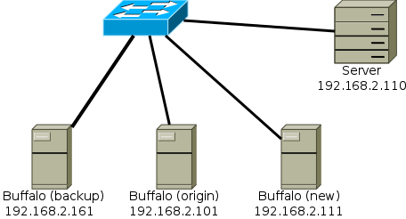

Figure 1: Outline of the network topology

This text is related to figure 1.

## 8.1 TikZ

[figure not shown]

Figure 2: A TikZ Image

This text is related to figure 2.

# 9 LaTeX

Some inline equation

[figure not shown]

written in LaTeX.

Some display math follows:

[figure not shown]

Next, using raw LaTeX inside Markdown

[figure not shown]

# 10 Special

## 10.1 Exec Filter

```
$ uname -r
4.2.0-25-generic
```

# References

Dierks, Tim, and Eric Rescorla. 2008. “The Transport Layer Security (TLS) Protocol Version 1.2.”

Schneier, Bruce. 2000. “Ten Risks of PKI: What You’re Not Being Told About Public Key Infrastructure.” *Computer Security Journal* 16 (1).

Vernam, Gilbert. 1919. “Secret Signaling System.” Google Patents. https://www.google.com/patents/US1310719.

Wikipedia. 2015. “Denuvo.” https://en.wikipedia.org/w/index.php?title=Denuvo&oldid=689469015.

[^1]: Footnote 1
[^2]: Footnote with longer reference
[^3]: inline footnote